# maps

various tutorials this is based on: https://rstudio.github.io/leaflet/basemaps.html https://ggplot2-book.org/maps.html https://towardsdatascience.com/making-interactive-maps-in-r-with-less-than-15-lines-of-code-bfd81f587e12

The GGplot method with geom_polygon()

```r
#data set
mi_counties <- map_data("county", "michigan") %>%
  select(lon = long, lat, group, id = subregion)
head(mi_counties)
```

```
##         lon      lat group     id
## 1 -83.88675 44.85686     1 alcona
## 2 -83.36536 44.86832     1 alcona
## 3 -83.36536 44.86832     1 alcona
## 4 -83.33098 44.83968     1 alcona
## 5 -83.30806 44.80530     1 alcona
## 6 -83.30233 44.77665     1 alcona
```

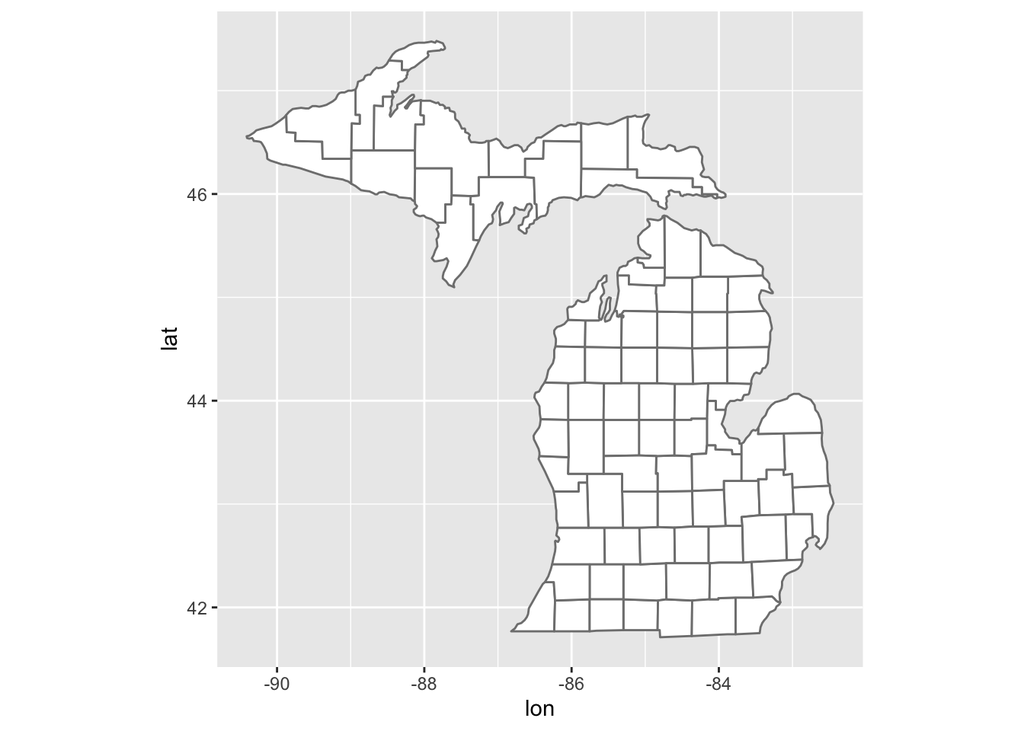

```r
#ggplot version of a map. More about this here: https://ggplot2-book.org/maps.html
ggplot(mi_counties, aes(lon, lat, group = group)) +
  geom_polygon(fill = "white", colour = "grey50") +
  coord_quickmap()
```

But let’s try it in leaflet because it is cooler.

```r
leaflet() %>%
  setView(lng = -71.0589, lat = 42.3601, zoom = 12) %>%
  addTiles()
```

[interactive chart not shown]

```r
#try to change this to be a map of Merced!
```

Other default tiles

Nasa: NASAGIBS.ViirsEarthAtNight2012 Google map: Esri.WorldImagery Gray: Esri.WorldGrayCanvas Terrain: Esri.WorldTerrain Topo Map: Esri.WorldTopoMap

Full list: http://leaflet-extras.github.io/leaflet-providers/preview/index.html

```r
leaflet() %>%
  setView(lng = -71.0589, lat = 42.3601, zoom = 12) %>%
  addProviderTiles(providers$Esri.WorldImagery)
```

[interactive chart not shown]

Pick to tiles to toggle between

```r
  leaflet() %>%
    addProviderTiles(providers$Esri.WorldGrayCanvas, group = "Grey") %>%
    addProviderTiles(providers$Esri.WorldTopoMap, group = "Topo")
```

[interactive chart not shown]

Add a third line of code to control the toggle

```r
  leaflet() %>%
    addProviderTiles(providers$Esri.WorldGrayCanvas, group = "Grey") %>%
    addProviderTiles(providers$Esri.WorldTopoMap, group = "Topo") %>%
    addLayersControl(baseGroups = c("Grey", "Topo"))
```

[interactive chart not shown]

Now let’s add some data on top! First read in a data file with latitude and longitude data

```r
museum <- read_csv("map_data/museum.csv")
```

Next we will pipe the data in

```r
museum %>% #here is where we are piping it in
  leaflet() %>%
    addProviderTiles(providers$Esri.WorldGrayCanvas, group = "Grey") %>%
    addProviderTiles(providers$Esri.WorldTopoMap, group = "Topo") %>%
    addLayersControl(baseGroups = c("Grey", "Topo"))
```

[interactive chart not shown]

Adding in markers from the data set

```r
museum %>%
  leaflet() %>%
    addProviderTiles(providers$Esri.WorldGrayCanvas, group = "Grey") %>%
    addProviderTiles(providers$Esri.WorldTopoMap, group = "Topo") %>%
    addLayersControl(baseGroups = c("Grey", "Topo"))  %>%
    addMarkers()#adding in markers from the museum dataset
```

```
## Assuming "lng" and "lat" are longitude and latitude, respectively
```

[interactive chart not shown]

adding labels to the markers

```r
museum %>%
  leaflet() %>%
    addProviderTiles(providers$Esri.WorldGrayCanvas, group = "Grey") %>%
    addProviderTiles(providers$Esri.WorldTopoMap, group = "Topo") %>%
    addLayersControl(baseGroups = c("Grey", "Topo"))  %>%
    addMarkers(label = museum$museum)#adding in the names of the museums
```

```
## Assuming "lng" and "lat" are longitude and latitude, respectively
```

[interactive chart not shown]

adding clusters

```r
museum %>%
  leaflet() %>%
    addProviderTiles(providers$Esri.WorldGrayCanvas, group = "Grey") %>%
    addProviderTiles(providers$Esri.WorldTopoMap, group = "Topo") %>%
    addLayersControl(baseGroups = c("Grey", "Topo"))  %>%
    addMarkers(label = museum$museum,
              clusterOptions = markerClusterOptions())
```

```
## Assuming "lng" and "lat" are longitude and latitude, respectively
```

[interactive chart not shown]

Adding mini map

```r
museum %>%
  leaflet() %>%
    addProviderTiles(providers$Esri.WorldGrayCanvas, group = "Grey") %>%
    addProviderTiles(providers$Esri.WorldTopoMap, group = "Topo") %>%
    addLayersControl(baseGroups = c("Grey", "Topo"))  %>%
    addMarkers(label = museum$museum,
              clusterOptions = markerClusterOptions())%>%
    addMiniMap(toggleDisplay = TRUE,
              tiles = providers$Esri.WorldGrayCanvas
              )
```

```
## Assuming "lng" and "lat" are longitude and latitude, respectively
```

[interactive chart not shown]

Full map comment out lines of code to see what they do!

```r
museum %>%
  leaflet() %>%
  addProviderTiles(providers$Esri.WorldImagery, group = "World Imagery") %>%
  addProviderTiles(providers$Stamen.TonerLite, group = "Toner Lite") %>%
  addLayersControl(baseGroups = c("Toner Lite", "World Imagery")) %>%
  addMarkers(label = museum$museum,
           clusterOptions = markerClusterOptions(),
           popup = ifelse(museum$`Presidential Library`=="Yes",
                          "A Presidential Library",
                          "Not a Presidential Library")) %>%
  setView(lat = 33.736309, lng = -84.388298, zoom = 11) %>%
  addMiniMap(
    toggleDisplay = TRUE,
    tiles = providers$Stamen.TonerLite
    )
```

```
## Assuming "lng" and "lat" are longitude and latitude, respectively
```

[interactive chart not shown]

Let’s try this with some fire data https://gis.data.ca.gov/datasets/CALFIRE-Forestry::nifc-2022-wildfire-perimeters-/about

```r
fire <- read_csv("map_data/fire.csv")
```

in order for leaflet to work it need columns with names lat and lng. So we rename the relevent columns in the data set.

```r
names(fire)[names(fire) == "irwin_InitialLatitude"] <- "lat"
names(fire)[names(fire) == "irwin_InitialLongitude"] <- "lng"
```

here’s what I came up with but play around add your own selections

```r
fire %>%
  leaflet() %>%
  addProviderTiles(providers$Esri.WorldImagery, group = "World Imagery") %>%
  addProviderTiles(providers$Stamen.TonerLite, group = "Toner Lite") %>%
  addLayersControl(baseGroups = c("Toner Lite", "World Imagery")) %>%
  addMarkers(label = fire$poly_IncidentName,
           popup = ifelse(fire$`irwin_FireCause`=="Human",
                          "Human", ifelse(fire$`irwin_FireCause`=="Natural",
                          "Natural", "Undetermined")))%>%
  setView(lat = 66.160507, lng = -153.369141, zoom = 4) %>%
  addMiniMap(
    toggleDisplay = TRUE,
    tiles = providers$Stamen.TonerLite)
```

```
## Assuming "lng" and "lat" are longitude and latitude, respectively
```

[interactive chart not shown]

If you want to change the color of markers check here: https://rstudio.github.io/leaflet/markers.html